[OHI Science](http://ohi-science.org) | [Citation policy](http://ohi-science.org/citation-policy/)

# Methods for cumulative impacts and their annual change

Compiled on Fri Dec 21 19:40:49 2018 by frazier

We describe change in the intensity of human-based activities on the global ocean during an 11 year period from 2003 to 2013 at a ~1km resolution. Specifically, we estimated the impact of 14 stressors based on the magnitude of the stressor as well as the vulnerability of 21 marine ecosystems to the stressor. The cumulative impact, which describes the impact of all stressors, was estimated by summing all 14 stressor impacts for each year. To determine annual change in stressor and cumulative impacts, we applied a linear regression model to each raster cell.

1. Linear regression slope estimates for cumulative and stressor impacts (n = 15 layers)
2. Cumulative impacts from 2003-2013 (n = 11 layers)
3. Stressor impacts for 14 stressors from 2003-2013 (n = 11 * 14 = 154 layers)
4. Stressor data for 14 stressors from 2003-2013, representing magnitude of the stressor scaled from 0-1 (n = 11 * 14 = 154 layers)
5. Ecosystem data (n = 21 layers)
6. Ecosystem x stressor vulnerability matrix (csv file)
7. R scripts used to calculate stressors and impacts

For more information about methods see Halpern et al. [2008](http://science.sciencemag.org/content/319/5865/948) and [2015](https://www.nature.com/articles/ncomms8615).

## 0.1 General model

We calculate stressor and cumulative impact $I_{c}$ at a ~1km resolution, using the following information:

Stressor impacts, $I_{s}$, were calculated for each of the 14 stressors by first multiplying the stressor intensity raster, $D_{j}$, by each ecosystem raster, $E_{i}$, and the corresponding vulnerability value, $mu _{ij}$. The stressor x ecosystem x vulnerability rasters are summed for each stressor and then divided by the number of habitats ($m$) in each raster cell:

$$I_{s} =
{\frac{1}{m} \sum\limits_{i=1}^{m}{D_{j} \times E_{i} \times} \mu _{ij}}$$

Cumulative impact, $I_{c}$, is calculated by summing the 14 stressor impact rasters:

$$I_{c} =
{\sum\limits_{i=1}^{m}{I_{s}}}$$

The scripts used to calculate the stressor impacts and cumulative impacts are available from: https://github.com/OHI-Science/impact_acceleration/tree/master/impacts (refer to README for details)

## 0.2 Data representation

All data are represented at ~1 km resolution with a WGS84 Mollweide projection. Nearly all of the source data used to derive the stressor layers had native coarser resolution (Table 2), and were therefore resampled/reprojected using nearest neighbor estimates of cell values. Using the nearest neighbor approach preserves the values of the original data, and assumes the coarse-scale value is evenly distributed across all 1km2 cells within that region. The coarser scale pattern is essentially recreated and finer resolution information is preserved where and when it is appropriate.

We use the WGS84 Mollweide projection because it preserves area so data towards the poles are not visually over-represented.

## 0.3 Stressors

We include stressors from 4 primary categories:

- Fishing: commercial demersal destructive, commercial demersal nondestructive high bycatch, commercial demersal nondestructive low bycatch, pelagic high bycatch, pelagic low bycatch, artisanal
- Climate change: sea surface temperature, ocean acidification, sea level rise
- Ocean: shipping
- Land-based: nutrient pollution, organic chemical pollution, direct human, light

Stressors included in our analyses are listed in Table S2 and S3 and described in detail below.

All scripts used to calculate stressors are available: https://github.com/OHI-Science/impact_acceleration/tree/master/stressors

### 0.3.1 General stressor information

Given our focus of describing *trends* in human impact on marine ecosystems, global datasets reporting results at regular intervals were critical. Given this constraint, we were unable to include some stressors from previous impact analyses (Halpern et al. 2008, 2015) because they did not include enough information for us to estimate annual change from 2003 to 2013. These include pressures requiring port traffic data (invasive species and ocean pollution), UV intensity, and benthic structures.

Other anthropogenic drivers we considered, but could not include due to incomplete spatial or temporal coverage, were: hypoxic zones, coastal engineering (piers, rock walls, etc.), non-cargo shipping (ferries, cruise ships, etc), aquaculture, disease, changes in sedimentation and freshwater input, and tourism.

Many of the habitats are only found near the coast, and to avoid biasing the results, the stressor raster data must extend all the way to the coastline (Frazier et al. 2016). In most cases, there were gaps in the data along the coastline. In some cases this occurred because monitoring missed some regions; however, it was most often due to converting a coarser resolution raster to a finer resolution raster, resulting in zig-zags of missing data along the coast. This made gapfilling necessary. We describe the methods used to gapfill each stressor.

Stressors are rescaled to have values between 0-1. Rescaling allows for direct comparison among drivers with dramatically different units of measurement. With the exception of ocean acidification, we rescaled the data by dividing by the 99.99th quantile across all global raster cells and years (values are capped to a maximum value of 1). We used all years of data to rescale the data to ensure comparability across time periods. The 99.99th quantile was used to minimize the influence of outliers. This approach assumes a linear relationship between the magnitude of the stressor and the impact on the ecosystem. This assumption ignores thresholds that likely exist but are known for very few stressors. For the ocean acidification stressor we were able to apply information about biological thresholds to rescale the data.

For many stressors, the distribution of values was highly skewed such that the highest, most extreme, values dictated the rescaling value. The result was that magnitude of intermediate values of the stressor were underestimated after rescaling. In these cases, we log transformed stressor values prior to rescaling. We indicate when data were transformed in descriptions of each stressor.

### 0.3.2 Stressor layer methods

*Table S2: Methods used to generate stressor data*

| stressor | preparing data | gapfilling | rescaling (0 to 1) | transformations |
| --- | --- | --- | --- | --- |
| sea surface temperature | Number of extreme SST weeks during a five year period subtracted from the number of extreme SST weeks during a baseline 5 year period (1985-1989). An extreme week is defined as having a SST anomaly (w… | Coastal cells without data estimated using mean of surrounding cells. Gapfilling performed on total annual extreme events. | raster value corresponding 99.99th quantile across all years | NA |
| ocean acidification | Monthly aragonite saturation values averaged to obtain annual estimates. | Coastal cells without data estimated using inverse distance weighting of rescaled data | Cell values $\leq$ 1 are given a pressure score of 1; for all other cells, rescaling is based on the change in saturation relative to the baseline period (average from 1880-1889) | NA |
| sea level rise | Monthly anomalies averaged to obtain annual mean sea level anomaly. 5 year mean of annual data used to smooth large yearly variation. | estimated missing coastal data using inverse distance weighting of 5 year mean anomaly data | raster value corresponding 99.99th quantile across all years | NA |
| fishing: artisanal | Total tonnes of catch from nonindustrial fisheries calculated for each year. Catch divided by corresponding year’s Net Primary Productivity (monthly data averaged for yearly NPP estimate) to standardi… | Fisheries catch and NPP gapfilled using average of nearest neighbors | raster value corresponding 99.99th quantile across all years | NPP log10 |
| fishing: demersal destructive | Total tonnes of catch for industrial demersal fishing using gear types causing habitat destruction calculated for each year. Catch data divided by corresponding year’s Net Primary Productivity (monthl… | Fisheries and NPP gapfilled using average of nearest neighbors | raster value corresponding 99.99th quantile across all years | NPP log10 |
| fishing: demersal nondestructive high bycatch | Total tonnes of catch for industrial demersal fishing using high bycatch practices calculated for each year. Catch data divided by corresponding year’s Net Primary Productivity (monthly data averaged … | Fisheries and NPP gapfilled using average of nearest neighbors | raster value corresponding 99.99th quantile across all years | NPP log10 |
| fishing: demersal nondestructive low bycatch | Total tonnes of catch for industrial demersal fishing using low bycatch practices calculated for each year. Catch data divided by corresponding year’s Net Primary Productivity (monthly data averaged f… | Fisheries and NPP gapfilled using average of neighbors | raster value corresponding 99.99th quantile across all years | NPP log10 |
| fishing: pelagic high bycatch | Total tonnes of catch for industrial pelagic fishing using high bycatch practices calculated for each year. Catch data divided by corresponding year’s Net Primary Productivity (monthly data averaged f… | Fisheries and NPP gapfilled using average of nearest neighbors | raster value corresponding 99.99th quantile across all years | NPP log10 |
| fishing: pelagic low bycatch | Total tonnes of catch for industrial pelagic fishing using low bycatch practices calculated for each year. Catch data divided by corresponding year’s Net Primary Productivity (monthly data averaged fo… | Fisheries and NPP gapfilled using average of neighbors | raster value corresponding 99.99th quantile across all years | NPP log10 |
| nutrient pollution (runoff) | Intensity of pollution from modeled plumes of land-based fertilizer pollution [(Halpern et al. 2008)](http://ohi-science.org/ohi-global/layers.html#nutrient_pollution), based on country level fertiliz… | NA | raster value corresponding to 99.99th quantile across all years | ln(x + 1) |
| organic chemical pollution (runoff) | Intensity of pollution from modeled plumes of land-based pesticide pollution [(Halpern et al. 2008)](http://ohi-science.org/ohi-global/layers.html#chemical_pollution), based on country level pesticide… | NA | raster value corresponding to 99.99th quantile across all years | ln(x + 1) |
| direct human | Density (people per km2) converted to population (people per raster cell). Intervening years (i.e., years outside of 2000, 2005, 2010, 2015, 2020) interpolated using a linear model. For each raster ce… | NA | raster value corresponding to average 99.99th quantile across all years | ln(x + 1) |
| light | Non-calibrated radiance values from satellite data calibrated across year/satellite following methods of Elvidge et al. 2009. | The dataset does not include the north and south pole regions, and these were estimated as zero | raster value corresponding 99.99th quantile across all years (excluding 0 values) | NA |
| shipping | Tournadre data used to create yearly rasters describing annual proportional change in shipping relative to 2011. Multiplied yearly proportional change raster and high resolution shipping raster (Halpe… | Outer border of Halpern et al. shipping data was gapfilled using mean of nearest neighbors; NA values for yearly shipping density were estimated as the total global change in shipping relative to 2011… | 99.99th quantile determined for each year (1992-2016) and the average of these values used to rescale data | ln(x + 1) |

##### 0.3.2.0.1 Fishing

*Commercial fishing (5 stressors)*

There are 5 commercial fishing stressors that describe different impacts on marine ecosystems:

- demersal destructive
- demersal non-destructive high bycatch
- demersal non-destructive low bycatch
- pelagic high bycatch
- pelagic low bycatch

The stressors were calculated using annual wild caught industrial fisheries catch (tonnes) by taxa and gear type at 0.5° resolution (Watson 2018, Global Fisheries Landings V3.0; Watson and Tidd 2018). For each stressor, we summed the relevant industrial tonnes of catch (Watson 2018) for each raster cell based on gear type and, in some cases, taxonomic information.

*Table S1. Gear types provided by Watson (2018) used to assign catch to each commercial fisheries pressure.*

| FleetGearName | bycatch | type | destruction |
| --- | --- | --- | --- |
| Trawl | high | demersal | destructive |
| Gillnet | high |  | non-destructive |
| Purse seine Non-tuna | low | pelagic | non-destructive |
| Lines Non-tuna | low |  | non-destructive |
| Trawl midwater | high | pelagic | non-destructive |
| Other | low |  | non-destructive |
| Dredge | high | demersal | destructive |
| Trap | high | demersal | non-destructive |
| Seine | high |  | non-destructive |
| LonglineTuna | high | pelagic | non-destructive |
| Pole and Line Tuna | low | pelagic | non-destructive |
| Purse seine Tuna | low | pelagic | non-destructive |
| Longline Non-tuna | high |  | non-destructive |

For catch records we were unable to confidently assign to the demersal or pelagic category based on gear type, we determined the taxa’s habitat using the “functional group” from the Sea Around Us taxon database (Pauly & Zeller 2015, seaaroundus.org).

There were some coastal raster cells without data. For these cells, we estimated the total catch within each stressor using the the mean of surrounding cells. Red areas in the following figure indicate gapfilled cells.

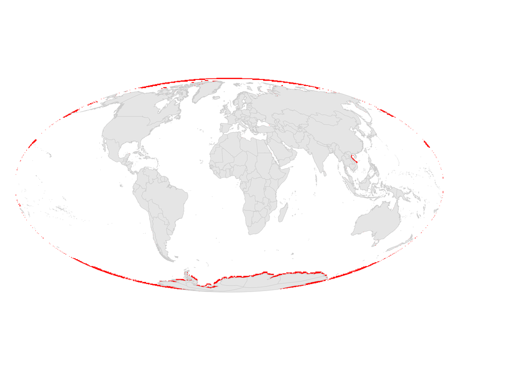

*Artisanal fishing*

The artisanal fishing stressor was calculated using annual wild caught nonindustrial fisheries catch (tonnes) at 0.5° resolution (Watson 2018). We summed nonindustrial tonnes catch (Watson 2018) for each raster cell, and otherwise, followed the methods used to estimate the commercial fishing stressors.

Gapfilled cells are the same as those from the commercial fishing stressors, described above.

##### 0.3.2.0.2 Climate change

*Sea surface temperature*

The sea surface temperature (SST) stressor describes the increased frequency of extreme temperature events relative to a historical baseline period. We used weekly SST anomaly data from version 6 of the Coral Reef Temperature Anomaly Database (CoRTAD) These data are a product of the NOAA National Oceanographic Data Center, produced using Advanced Very High Resolution Radiometer (AVHRR) Pathfinder SST data (https://data.nodc.noaa.gov/cgi-bin/iso?id=gov.noaa.nodc:NCEI-CoRTADv6). SST anomalies are defined as the weekly SST minus weekly climatological SST, as calculated across all years of data (1982-2017).

The number of weeks, during a five year period, with extremely warm SST was subtracted from the number of extreme SST weeks during a five year baseline period (1985-1989). An extreme SST event was defined as a week when the SST anomaly exceeded the standard deviation of SST anomalies for that location (i.e., grid cell) and week of the year. Extreme events included only high (i.e., warming) SST events.

We use 5 year periods (e.g., 2013 data includes extreme events from 2009-2013) to smooth yearly variation that is not due to long-term climate change.

There were some coastal raster cells without data. For these cells, we estimated the total annual extreme events using the the mean of surrounding cells. Red areas in the following figure indicate gapfilled cells.

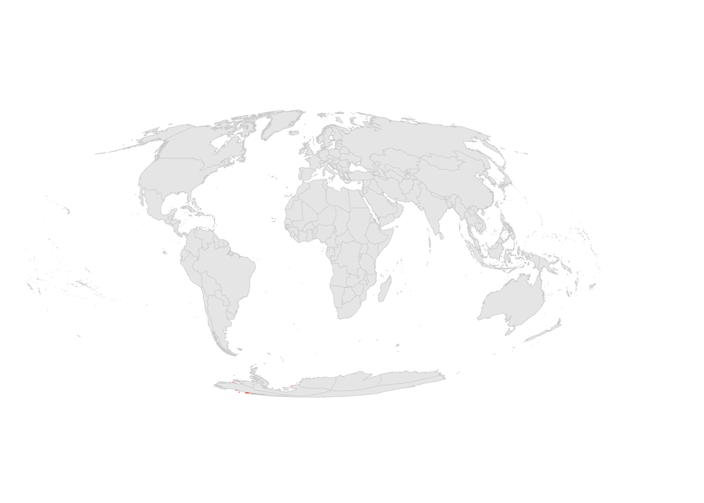

*Ocean acidification*

The ocean acidification stressor describes the magnitude of decreasing aragonite saturation state ($\Omega_{arag}$) due to increasing atmospheric CO<sub>2</sub> levels from human influences. Monthly data are provided at 1° resolution (Feely et al. 2009). Monthly data are averaged to obtain yearly estimates of aragonite saturation state.

This stressor is unique in that the data are rescaled to values between 0 and 1 using a biological threshold rather than the 99.99th quantile across raster cells and year. When values are $\leq$ 1, the threshold at which seawater becomes undersaturated, the pressure is 1 (the highest pressure). For values >1, rescaling is based on the change in saturation relative to a baseline period (average from 1880-1889), using the following formula:

$$Stress = \frac{(\Omega_{baseline} - \Omega_{year})}{(\Omega_{baseline} - 1)}$$

The current value is subtracted from the baseline so a reduction in $\Omega$ becomes a positive pressure value. This value is then divided by the baseline minus one so a decrease in $\Omega$ while the current state is relatively high results in lower pressure than the same decrease when the current state is near 1.

Increases in aragonite saturation state result in pressure = 0.

There were some coastal raster cells without data. For these cells, we estimated the annual stressor values using an inverse distance weighting method. Red areas in the following figure indicate gapfilled cells.

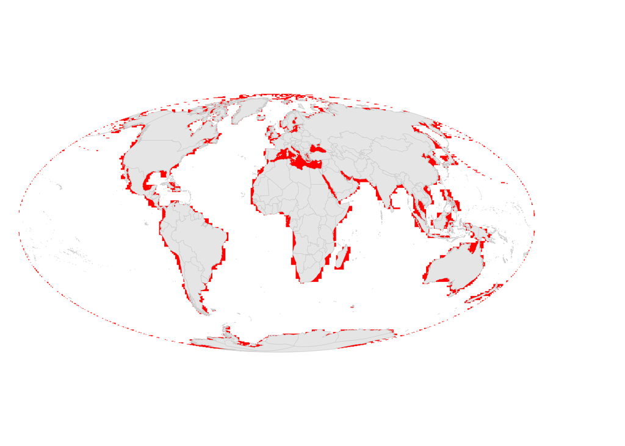

*Sea level rise*

We ultimately used 5 years of anomaly data to calculate each year of stressor data, such that the 2013 stressor layer includes 2009-2013 data, due to large yearly variation in SLR.

All negative values were set to zero (i.e., no negative pressure), such that only positive sea level rise values are considered.

There were some coastal raster cells without data. For these cells, we estimated missing 5 year average sea level rise anomalies using an inverse distance weighting method. Red areas in the following figure indicate gapfilled cells.

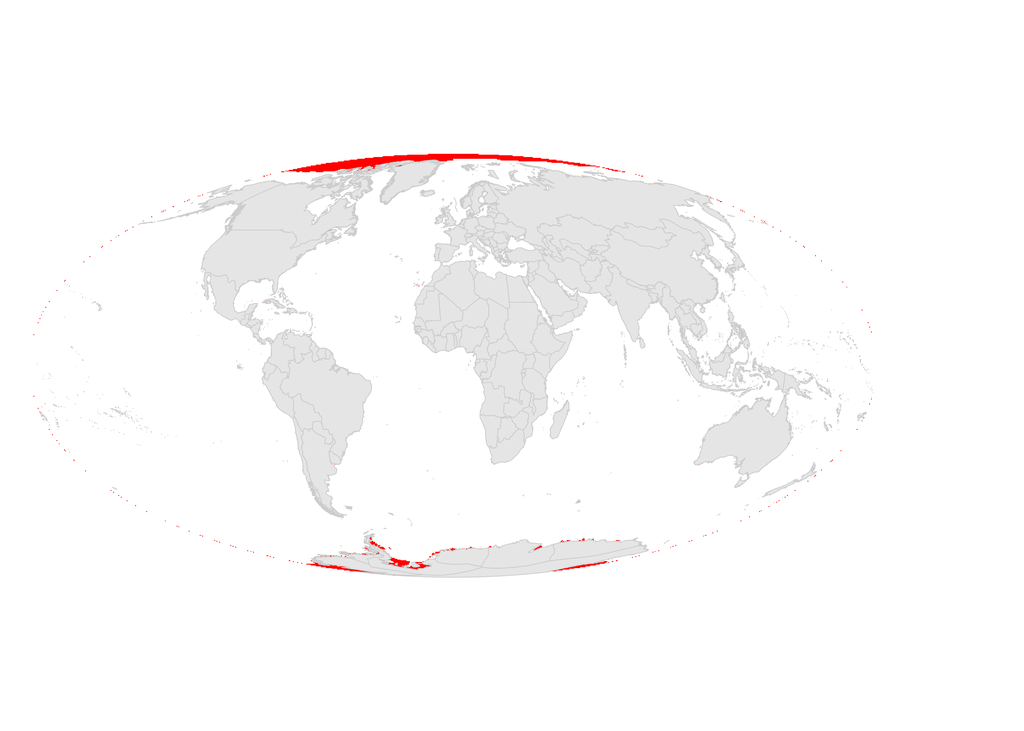

##### 0.3.2.0.3 Ocean-based

*Shipping*

This pressure describes intensity of global shipping traffic. High quality, freely available, annual shipping data are currently unavailable. Consequently, we combined two sources of data to describe spatial and temporal shipping patterns.

The first data source was a high resolution (0.1°) map of global vessel traffic based on data from the Volunteer Observing System (VOS) and Automatic Identification System (AIS) (data from Halpern et al. 2015; Wallbridge 2013). These data combine several years of shipping data but are mostly a static description of shipping during 2011. The outer border of these shipping data was gapfilled using mean of nearest neighbors.

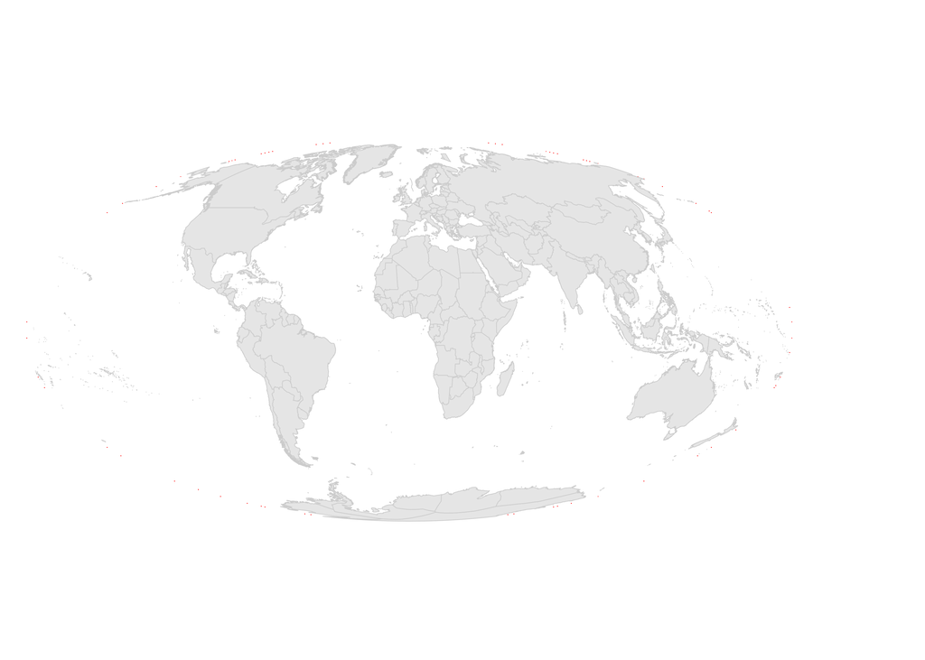

Data were ln(x+1) transformed due to extreme skew.

##### 0.3.2.0.4 Land-based

*Nutrient pollution*

The nutrient pollution stressor describes relative intensity of nutrient pollution due to run-off from land-based applications. These data represent modeled nutrient plumes resulting from land-based nitrogen application at ~1km resolution. A brief overview of the methods are provided below, but see Halpern et al. (2008, 2015) for more information.

The plume model uses country-level average annual fertilizer use (as a proxy for nutrient pollution) from FAO (http://faostat3.fao.org/faostat-gateway/go/to/browse/R/*/E). Missing values were estimated using a linear regression model between fertilizer and pesticides when possible, and otherwise with agricultural GDP. Data were summed across all fertilizer compounds and reported in metric tons. Upon inspection the data included multiple 0 values that are most likely data gaps in the time-series, so they were treated as such and replaced with NA. Uninhabited countries were assumed to have no fertilizer use and thus excluded.

Country-level pollution values were then dasymetrically distributed over a country’s landscape using global landcover data, derived from the Moderate Resolution imaging Spectroradiometer (MODIS) instrument at ~500m resolution (Channan et al. 2014, Friedl et al. 2010).

These values were then aggregated by ~140,000 global basins, and diffusive plumes were modeled from each basin’s pourpoint. Watershed boundaries were developed with an automated flow-accumulation process (Jenson and Domingue 1988) on the basis of 30 arc-second (nominally 1km2) SRTM30 Digital Elevation Model (DEM) data (USGS 2004).

The final non-zero plumes (about ~76,000) were aggregated into ~1km Mollweide (wgs84) projection rasters to produce a single plume-aggregated pollution raster.

Data were ln(x+1) transformed.

*Organic chemical pollution*

The organic chemical pollution stressor describes the amount of organic chemical pollution from land-based applications and run-off. We use FAO data describing country-level pesticide use as a proxy measure for organic pollution. Otherwise, the methods are the same as those for nutrient pollution.

*Direct human*

Population density was converted to population (people per cell) based on raster cell size. We summed the coastal human population, defined as the number of people within a moving circular window around an arbitrary focal coastal cell of radius 10 km. Data were cropped to include only cells 1km from the coast because this stressor primarily affects intertidal and very nearshore ecosystems.

Values were ln(x+1) transformed.

*Light*

The light stressor describes the amount of light pollution in marine environments. We used annual DMSP stable night lights satellite data (Elvidge et al. 2009; https://ngdc.noaa.gov/eog/data/web_data/v4composites/%s.v4.tar, image and data processing by NOAA’s National Geophysical Data Center; DMSP satellite data collected by US Air Force Weather Agency) with resolution of 30 arc-seconds spanning -65 to 75 degrees latitude and -180 to 180 degrees longitude. The original data contained non-calibrated radiance values, ranging from 0-63, with different satellites used to collect the data across years.

For each year, the original raster values of 0-63 ($DNo$) were calibrated to produce adjusted, $DNa$, values, using the following formula:

$$DNa = C0 + C1*DNo + C2*DNo^2$$

C0, C1 and C1 coefficients used to calibrate the data were estimated using data only from the Sicily region which was selected because it is not light saturated and is thought to have remained fairly constant over the years. Coefficients for each year were estimated using a 2nd degree polynomial regression model, with the F121999 satellite as a predictor variable, with the model coded in R as:

$DNo_{year}$ ~ 0 + poly($DNo_{F121999}$, 2, raw=TRUE)

The intercept was forced through the origin, so cells with zero light were estimated as zero values (indicated by the 0 value in the regression model).

We followed Elvidge et al. (2009) and used the F121999 satellite as the reference based on their assessment, that:

> In reviewing the data it was found that the data from satellite year F121999 had the highest digital values. Because there is saturation (DN = 63) in the bright cores of urban centers and large gas flares, F121999 was used as the reference and the data from all other satellite years were adjusted to match the F121999 data range.

This approach assumes the reference area of Sicily has had little change in light output during this period. This technique, while not perfect, does allow for better comparison between different satellites and time periods.

There is the possibility of missing cells due to cloud cover. These have a value of 255 in the data. For the most part, these cells do not appear in the ocean. In case there were a few of these scattered about, these values were replaced with zero. Also the data does not fully cover the north and south pole regions, and these were estimated as zero values.

### 0.3.3 Stressor data sources

*Table S3: Data sources for stressor data*

[output not shown]

## 0.4 Marine ecosystems

20 of the 21 marine ecosystems used to estimate impacts remain unchanged from previous impact assessments (Halpern et al. 2008, 2015). This year we added a sea ice edge ecosystem, which currently functions as more of a placeholder because the pressures included in the assessment have limited effected on seaice habitat, which is known to be rapidly changing. We currently do not include UV or air temperature data. We do include SST, but these data are inaccurate in the presence of sea ice. For this reason, we do not include this habitat in our summaries.

The marine ecosystem data is represented as rasters with areas with the habitat indicated by values of 1 (otherwise values are NA). However, because sea ice is so temporally variable, sea ice edge values range from 0-1 based on the proportion of the year that sea ice edge is present.

We use monthly Sea Ice Concentrations from Nimbus-7 SMMR and DMSP SSM/I-SSMIS Passive Microwave Data collected from 1981 to 2010. We identified sea ice edge cells as those with concentrations between 15-80% (based on: http://seaiceatlas.snap.uaf.edu/glossary), and assigned them a value of 1 (otherwise 0). Using the classified sea ice edge data, monthly rasters across all years were averaged to determine the proportion of time the raster is classified as sea ice edge habitat. There is a “hole” of missing data at the northern most part of globe due to satellite coverage, this area was classified as 0, indicating solid ice. We estimated shoreline cells without data using the average of nearest neighbors.

## 0.5 Vulnerability matrix

*Table S4. Vulnerability of each ecosystem to each stressor.*

| pressure | beach | coral reef | deep hard bottom | deep seamount | deep soft benthic | deep water | hard shelf (60-200m) | hard slope (200-2000m) | ice edge | intertidal mud | kelp forest | mangrove | rocky intertidal | rocky reef | salt marsh | seagrass | soft shelf (60-200m) | soft slope (200-2000m) | subtidal soft bottom | surface water | susp. feeder reef |
| --- | --- | --- | --- | --- | --- | --- | --- | --- | --- | --- | --- | --- | --- | --- | --- | --- | --- | --- | --- | --- | --- |
| artisanal fishing | 0.7 | 2.3 | 0 | 0.9 | 0.3 | 0 | 1.9 | 0.4 | 0 | 0.4 | 0.8 | 1.7 | 1.3 | 2.2 | 0.6 | 0.3 | 0.9 | 0 | 0 | 1 | 1 |
| comm fish: dem dest | 0.2 | 1.2 | 3 | 3.5 | 2.3 | 0.8 | 3.1 | 2.8 | 0 | 1.4 | 1.5 | 0 | 1.2 | 2.7 | 1 | 0.2 | 3 | 3.2 | 2.1 | 2.1 | 3.1 |
| comm fish: dem nondest hb | 0.9 | 1.6 | 0 | 0 | 2 | 0 | 3.2 | 2.4 | 0 | 1.9 | 2.1 | 0.9 | 0.8 | 2.9 | 1 | 1.1 | 2 | 2.3 | 2.1 | 1.6 | 0.7 |
| comm fish: dem nondest lb | 0.7 | 1.2 | 0 | 0 | 1.5 | 0 | 2.4 | 1.8 | 0 | 1.4 | 1.6 | 0.7 | 0.6 | 2.2 | 0.8 | 0.8 | 1.5 | 1.8 | 1.6 | 1.2 | 0.5 |
| comm fish: pel hb | 0.1 | 0.5 | 0 | 0 | 1.6 | 2.2 | 2.8 | 0 | 0 | 0 | 0 | 0 | 0.9 | 2.6 | 0.5 | 0 | 1.1 | 0.2 | 0 | 3 | 0 |
| comm fish: pel lb | 0 | 0.7 | 0 | 0 | 0.5 | 0.6 | 2.8 | 0 | 0 | 0 | 0 | 0 | 0 | 2.6 | 0.4 | 0 | 0.8 | 0.2 | 0.6 | 2.2 | 0 |
| direct human | 2.7 | 2.3 | 0 | 0 | 1.6 | 0 | 2.9 | 0 | 2.6 | 2.2 | 1.6 | 3.3 | 2.8 | 2.5 | 1.6 | 2.5 | 1.1 | 0 | 2 | 0.9 | 3 |
| light pollution | 2 | 1 | 0 | 0 | 0 | 0 | 0 | 0 | 0 | 1.4 | 0.5 | 0.9 | 1.4 | 0.7 | 1.8 | 0.5 | 0 | 0 | 0.5 | 0.4 | 1 |
| nutrient pollution | 0.4 | 1.8 | 0 | 0 | 1.3 | 0 | 1.7 | 0.6 | 0 | 1.6 | 0.4 | 1.8 | 1.6 | 1.6 | 1.9 | 2.1 | 1.4 | 2 | 2 | 1.2 | 1.4 |
| oa | 0 | 1.1 | 2.7 | 2.7 | 2.2 | 0 | 2.5 | 1.6 | 0 | 1 | 0 | 1.2 | 0.9 | 1.1 | 1.3 | 1.4 | 1.7 | 2.1 | 0.1 | 1.8 | 0.7 |
| organic pollution | 0.1 | 1.2 | 0 | 0 | 1.7 | 1.6 | 0 | 0.2 | 2.2 | 2.8 | 1 | 1.4 | 2.1 | 2.2 | 1.7 | 1 | 1.4 | 2 | 1.2 | 1.9 | 2.8 |
| shipping | 1.9 | 1.5 | 0 | 0 | 0.9 | 0 | 0.9 | 1 | 0 | 1.9 | 0 | 2 | 0.3 | 1.4 | 1.4 | 1.9 | 1.7 | 0.1 | 0.3 | 1.9 | 0 |
| slr | 2.1 | 2.4 | 0 | 0 | 0 | 0 | 0 | 0 | 0 | 1.9 | 1.6 | 3 | 2.5 | 1.5 | 3.1 | 2.6 | 0 | 0 | 2.2 | 0 | 1.8 |
| sst | 0.6 | 2.8 | 1.5 | 1.8 | 2.5 | 2.3 | 2.9 | 0.9 | 3.8 | 1.4 | 2 | 2.4 | 2.8 | 1.9 | 1.4 | 2.1 | 2.5 | 2.3 | 0.5 | 3.3 | 0.8 |

## 0.6 References

AVISO (2016). Satellite Alimetry Data: Mean sea level rise. https://www.aviso.altimetry.fr/en/data/products/sea-surface-height-products/global/msla-mean-climatology.html

Behrenfeld, M.J., and Falkowski, P.G. (1997). Photosynthetic rates derived from satellite-based chlorophyll concentration. Limnology and Oceanography 42, 1–20.

Center for International Earth Science Information Network - CIESIN - Columbia University (2017). Gridded Population of the World, Version 4 (GPWv4): Population Density Adjusted to Match 2015 Revision UN WPP Country Totals. Palisades, NY: NASA Socioeconomic Data and Applications Center (SEDAC). https://doi.org/10.7927/H49884ZR

Channan, S., K. Collins, and W. R. Emanuel (2014). Global mosaics of the standard MODIS land cover type data. University of Maryland and the Pacific Northwest National Laboratory, College Park, Maryland, USA.

Elvidge, C.D., Ziskin, D., Baugh, K.E., Tuttle, B.T., Ghosh, T., Pack, D.W., Erwin, E.H., and Zhizhin, M. (2009). A Fifteen Year Record of Global Natural Gas Flaring Derived from Satellite Data. Energies 2, 595–622.

Feely, R., Doney, S., and Cooley, S. (2009). Ocean acidification: present conditions and future changes in a high-CO2 world. Oceanography 22, 36–47.

Frazier, M., Longo, C., and Halpern, B.S. (2016). Mapping uncertainty due to missing data in the global Ocean Health Index. PLOS ONE 11, e0160377.

Friedl, M.A., D. Sulla-Menashe, B. Tan, A. Schneider, N. Ramankutty, A. Sibley and X. Huang (2010), MODIS Collection 5 global land cover: Algorithm refinements and characterization of new datasets, 2001-2012, Collection 5.1 IGBP Land Cover, Boston University, Boston, MA, USA. http://www.landcover.org/data/lc/

Halpern, B.S., Walbridge, S., Selkoe, K.A., Kappel, C.V., Micheli, F., D’Agrosa, C., Bruno, J.F., Casey, K.S., Ebert, C., Fox, H.E., et al. (2008). A Global Map of Human Impact on Marine Ecosystems. Science 319, 948–952.

Halpern, B.S., Frazier, M., Potapenko, J., Casey, K.S., Koenig, K., Longo, C., Lowndes, J.S., Rockwood, R.C., Selig, E.R., Selkoe, K.A., et al. (2015). Spatial and temporal changes in cumulative human impacts on the world’s ocean. Nat Commun 6, 7615.

Jenson, S.K., and Domingue, J.O. (1988). Extracting Topographic Structure from Digital Elevation Data for Geographic Information System Analysis. Photogrammetric Engineering and Remote Sensing. 54: 1593-1600. https://www.asprs.org/wp-content/uploads/pers/1988journal/nov/1988_nov_1593-1600.pdf

Pauly, D., and Zeller, D. (2015). Sea around us concepts, design and data. seaaroundus.org

Saha, K., Zhao, X., Zhang, H., Casey, K.S.. Zhang, D., Zhang, Y., Baker-Yeboah, S., Relph, J.M., Krishnan, A., Ryan, T. (2018). The Coral Reef Temperature Anomaly Database (CoRTAD) Version 6 - Global, 4 km Sea Surface Temperature and Related Thermal Stress Metrics for 1982 to 2017. NOAA National Centers for Environmental Information. Dataset. August 21, 2018.

Selig, E.R., Casey, K.S., and Bruno, J.F. (2010). New insights into global patterns of ocean temperature anomalies: implications for coral reef health and management. Global Ecology and Biogeography 19, 397–411.

Tournadre, J. (2014). Anthropogenic pressure on the open ocean: The growth of ship traffic revealed by altimeter data analysis. Geophysical Research Letters 41, 7924–7932.

United Nations (2016). FAO Statistics Division - Inputs. http://faostat3.fao.org/browse/R/*/E

USGS (2004). Shuttle Radar Topography Mission, 30 Arc Second, SRTM30 Digital Elevation Model (DEM), Global Land Cover Facility, University of Maryland, College Park, Maryland, February 2000. http://glcf.umd.edu/data/srtm/

Wallbridge, S. (2013). Assessing ship movements using volunteered geographic information. University of California, Santa Barbara. Masters Thesis. https://4326.us/thesis/walbridge-masters-thesis.pdf

Watson, R.A., and Tidd, A. (2018). Mapping nearly a century and a half of global marine fishing: 1869–2015. Marine Policy 93, 171–177.

Watson, R.A. (2018). Global Fisheries Landings V3.0. http://metadata.imas.utas.edu.au/geonetwork/srv/eng/metadata.show?uuid=ff1274e1-c0ab-411b-a8a2-5a12eb27f2c0.